# Comparison of more than 2 groups

2023-09-29

```r
set.seed(12345)
amess=read.csv('amess.csv', header=TRUE)
```

Data set that contains observations of 3 groups of red cell folate levels of cardiac bypass patients.

**Group 1:** 50% N2O and 50% O2 continuously for 24 hours

**Group 2:** 50% N2O and 50% O2 during the operation

**Group 3:** No N2O but 35-50% O2 continuously for 24 hours

**Global Hypothesis:**

H0: There is no clear or significant difference between any of the groups red blood cell folate levels.

Ha: At least one of the groups will have a significant difference compared to the other groups red blood cell folate levels.

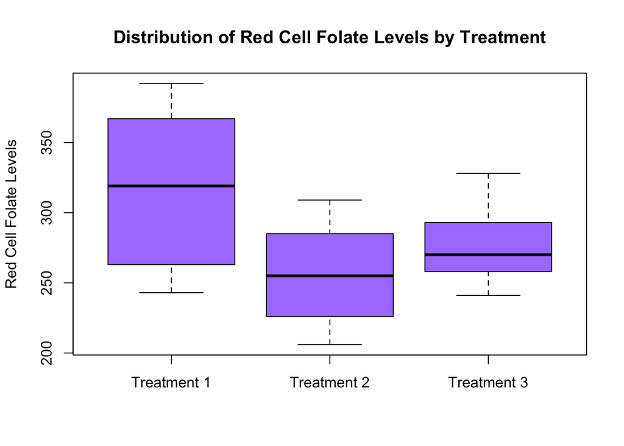

# # Pairwise t-tests

Since we are looking at 3 different groups to compare, we need to perform 3 pairwise comparisons. Each groups needs to be compared to one another as it will give us a better idea of the differences between each group.

```r
amess$treatmnt <- factor(amess$treatmnt, levels = 1:3, labels = c("50% N2O and 50% O2 continuously for 24 hours", "50% N2O and 50% O2 during the operation", "No N2O but 35-50% O2 continuously for 24 hours"))

pairwise.t.test(amess$folate, amess$treatmnt, p.adj = "none")
```

```
##
##  Pairwise comparisons using t tests with pooled SD
##
## data:  amess$folate and amess$treatmnt
##
##                                                50% N2O and 50% O2 continuously for 24 hours
## 50% N2O and 50% O2 during the operation        0.014
## No N2O but 35-50% O2 continuously for 24 hours 0.155
##                                                50% N2O and 50% O2 during the operation
## 50% N2O and 50% O2 during the operation        -
## No N2O but 35-50% O2 continuously for 24 hours 0.408
##
## P value adjustment method: none
```

P values in each group comparison:

Group1+Group2: 0.014

Group2+Group3: 0.408

# # Prove the Alpha level

```r
num_pairwise <- 3

num_simulation <- 1000

global_dec <- numeric(num_simulation)

pairwise_dec <- matrix(0, nrow = num_simulation, ncol = num_pairwise)

for (i in 1:num_simulation) {
  sim_p_values <- runif(num_pairwise)

  global_dec[i] <- any(sim_p_values < 0.05)

  pairwise_dec[i, ] <- sim_p_values < 0.05
}

# Calculate the estimated alpha level (type-1 error) for the global null hypothesis
alpha_global <- mean(global_dec)
cat("Global Alpha level:", alpha_global, "\n")
```

```
## Global Alpha level: 0.141
```

```r
# Calculate the alpha level for each pairwise comparison
alpha_pairwise <- colMeans(pairwise_dec)
cat("Alpha Level for all Pairwise Comparisons:", alpha_pairwise, "\n")
```

```
## Alpha Level for all Pairwise Comparisons: 0.055 0.046 0.048
```

As we can see from the calculated alpha level for each comparison is different from the calculated global alpha level. The global alpha level being higher means that there’s more room for error to pass through vs when looking at a pairwise comparison we have a “stricter” error level. The pairwise have a more accurate alpha level when compared to the combined global alpha level. We can also see more of a difference in the comparisons of the groups vs just looking at the alpha level which a combined value of each group.